# Tarea Gradient Boosting

```r
library(rgeos)
library(maptools)
library(maps)
library(gbm)
library(kknn)
library(Hmisc)
library(glmnet)
library(magrittr)
```

### Datos

Consideraremos otro problema de predicción de valor de casas en el estado de California. Necesitaremos estos dos paquetes para hacer gráficas

Opcional: haz el ejercicio con los paquetes xgboost y pdp.

La descripción de los datos es:

&P Letters Data We collected information on the variables using all the block groups in California from the 1990 Census. In this sample a block group on average includes 1425.5 individuals living in a geographically compact area. Naturally, the geographical area included varies inversely with the population density. We computed distances among the centroids of each block group as measured in latitude and longitude. We excluded all the block groups reporting zero entries for the independent and dependent variables. The final data contained 20,640 observations on 9 variables. The dependent variable is ln(median house value).

INTERCEPT  
MEDIAN INCOME  
MEDIAN INCOME2  
MEDIAN INCOME3  
ln(MEDIAN AGE)  
ln(TOTAL ROOMS/ POPULATION) ln(BEDROOMS/ POPULATION)  
ln(POPULATION/ HOUSEHOLDS)  
ln(HOUSEHOLDS)

The file cadata.txt contains all the the variables. Specifically, it contains median house value, median income, housing median age, total rooms, total bedrooms, population, households, latitude, and longitude in that order.

Reference

Pace, R. Kelley and Ronald Barry, Sparse Spatial Autoregressions, Statistics and Probability Letters, 33 (1997) 291-297.

Puedes encontrar los datos en la carpeta datos del repositorio (california_housing)

Podemos ver la ubicación de los block groups:

```r
data <- read.table("../../../datos/california_housing/cadata.txt", skip=27, sep="",
    strip.white=TRUE)
nrow(data)
```

```
## [1] 20640
```

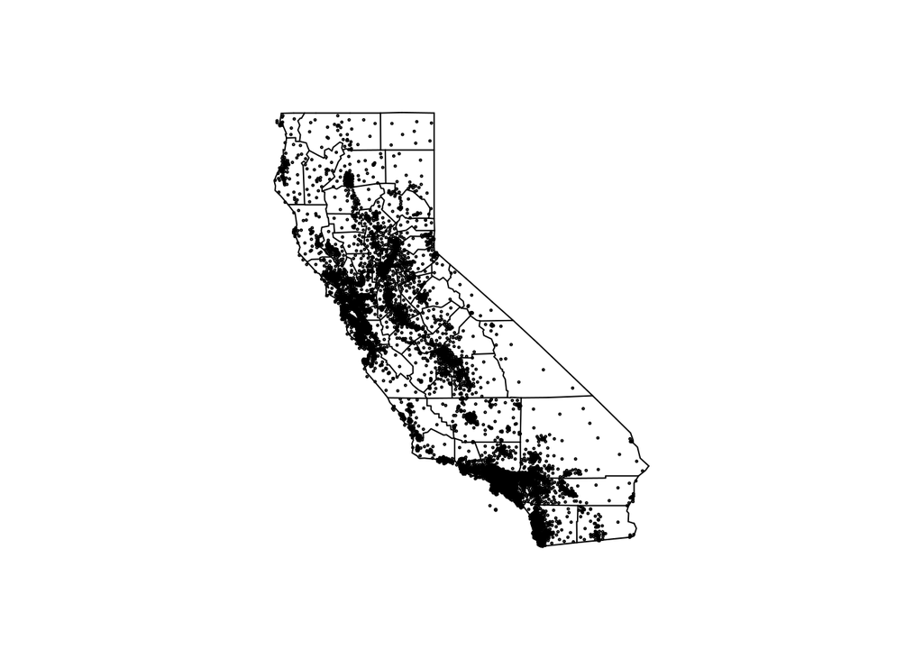

```r
names(data) <- c("med_value","med_income","housing_med_age",
    "total_rooms","total_bedrooms",
    "pop","households","lat","long")

map('county','california')
points(data$long, data$lat,cex=0.2)
```

```r
nrow(data)
```

```
## [1] 20640
```

Podemos normalizar algunas variables y cambiar unidades para que sea más fácil interpretar

```r
#promedio de cuartos por hogar
data$ave_room <- data$total_rooms/data$households
data$ave_bedroom <- data$total_bedrooms/data$households
# escalado de  valor (cientos de miles de dólares)
data$med_value_scaled <- data$med_value/100000
#promedio de número de habitantes por número de hogares
data$ave_occupancy <- data$pop/data$households
#ojo: gbm usa el orden de los datos
set.seed(122323)
data_f <- data[sample(1:nrow(data), nrow(data)),]
```

### Pregunta 1

- Discute validación y prueba

Separamos datos de entrenamiento y prueba (vamos a usar validación cruzada para seleccionar modelos):

```r
data_f_valid <- data_f[1:4000,]
data_f_train <- data_f[4000:20640, ]
```

*Considerando esta separación: observo que es diferente, aunque similar en el valor medio de las casas `med_value` tanto en los promedios, como en los mínimos. Por lo que podríamos decir que estamos utilizando solo una sección de los datos.*

```r
"Validación"
```

```
## [1] "Validación"
```

```r
summary(data_f_valid)
```

```
##    med_value        med_income     housing_med_age  total_rooms
##  Min.   : 22500   Min.   : 0.536   Min.   : 2.00   Min.   :   15
##  1st Qu.:118675   1st Qu.: 2.532   1st Qu.:19.00   1st Qu.: 1438
##  Median :178300   Median : 3.471   Median :29.00   Median : 2125
##  Mean   :204061   Mean   : 3.806   Mean   :28.77   Mean   : 2618
##  3rd Qu.:262025   3rd Qu.: 4.625   3rd Qu.:37.00   3rd Qu.: 3134
##  Max.   :500001   Max.   :15.000   Max.   :52.00   Max.   :30450
##  total_bedrooms        pop          households          lat
##  Min.   :   3.0   Min.   :    5   Min.   :   2.0   Min.   :32.55
##  1st Qu.: 297.0   1st Qu.:  798   1st Qu.: 279.8   1st Qu.:33.94
##  Median : 436.0   Median : 1166   Median : 410.0   Median :34.26
##  Mean   : 539.1   Mean   : 1420   Mean   : 499.7   Mean   :35.66
##  3rd Qu.: 644.2   3rd Qu.: 1718   3rd Qu.: 602.2   3rd Qu.:37.72
##  Max.   :5033.0   Max.   :10493   Max.   :4616.0   Max.   :41.88
##       long           ave_room       ave_bedroom     med_value_scaled
##  Min.   :-124.3   Min.   : 1.912   Min.   : 0.375   Min.   :0.225
##  1st Qu.:-121.8   1st Qu.: 4.412   1st Qu.: 1.006   1st Qu.:1.187
##  Median :-118.5   Median : 5.180   Median : 1.048   Median :1.783
##  Mean   :-119.6   Mean   : 5.423   Mean   : 1.102   Mean   :2.041
##  3rd Qu.:-118.0   3rd Qu.: 6.005   3rd Qu.: 1.099   3rd Qu.:2.620
##  Max.   :-114.3   Max.   :59.875   Max.   :15.312   Max.   :5.000
##  ave_occupancy
##  Min.   :  1.066
##  1st Qu.:  2.442
##  Median :  2.826
##  Mean   :  3.066
##  3rd Qu.:  3.291
##  Max.   :502.462
```

```r
dim(data_f_valid)
```

```
## [1] 4000   13
```

```r
"Entrenamiento"
```

```
## [1] "Entrenamiento"
```

```r
summary(data_f_train)
```

```
##    med_value        med_income      housing_med_age  total_rooms
##  Min.   : 14999   Min.   : 0.4999   Min.   : 1.00   Min.   :    2
##  1st Qu.:120000   1st Qu.: 2.5694   1st Qu.:18.00   1st Qu.: 1451
##  Median :180100   Median : 3.5481   Median :29.00   Median : 2127
##  Mean   :207529   Mean   : 3.8861   Mean   :28.61   Mean   : 2640
##  3rd Qu.:265500   3rd Qu.: 4.7708   3rd Qu.:37.00   3rd Qu.: 3150
##  Max.   :500001   Max.   :15.0001   Max.   :52.00   Max.   :39320
##  total_bedrooms        pop          households          lat
##  Min.   :   1.0   Min.   :    3   Min.   :   1.0   Min.   :32.54
##  1st Qu.: 295.0   1st Qu.:  785   1st Qu.: 280.0   1st Qu.:33.93
##  Median : 435.0   Median : 1166   Median : 409.0   Median :34.25
##  Mean   : 537.6   Mean   : 1427   Mean   : 499.5   Mean   :35.63
##  3rd Qu.: 648.0   3rd Qu.: 1726   3rd Qu.: 605.0   3rd Qu.:37.71
##  Max.   :6445.0   Max.   :35682   Max.   :6082.0   Max.   :41.95
##       long           ave_room         ave_bedroom      med_value_scaled
##  Min.   :-124.3   Min.   :  0.8461   Min.   : 0.3333   Min.   :0.150
##  1st Qu.:-121.8   1st Qu.:  4.4475   1st Qu.: 1.0061   1st Qu.:1.200
##  Median :-118.5   Median :  5.2395   Median : 1.0490   Median :1.801
##  Mean   :-119.6   Mean   :  5.4303   Mean   : 1.0954   Mean   :2.075
##  3rd Qu.:-118.0   3rd Qu.:  6.0636   3rd Qu.: 1.0996   3rd Qu.:2.655
##  Max.   :-114.5   Max.   :141.9091   Max.   :34.0667   Max.   :5.000
##  ave_occupancy
##  Min.   :   0.6923
##  1st Qu.:   2.4280
##  Median :   2.8168
##  Mean   :   3.0717
##  3rd Qu.:   3.2799
##  Max.   :1243.3333
```

```r
dim(data_f_train)
```

```
## [1] 16641    13
```

```r
rm(data_f_train, data_f_valid)
```

*Utilizando una muestra aleatoria.*

```r
set.seed(175904)
sample <- sample(1:nrow(data_f), 4000)
data_f_valid2 <- data_f[sample,]
data_f_train2 <- data_f[-sample, ]
rm(sample)
"train"
```

```
## [1] "train"
```

```r
summary(data_f_train2)
```

```
##    med_value        med_income      housing_med_age  total_rooms
##  Min.   : 14999   Min.   : 0.4999   Min.   : 1.00   Min.   :    2
##  1st Qu.:118975   1st Qu.: 2.5588   1st Qu.:18.00   1st Qu.: 1444
##  Median :179650   Median : 3.5341   Median :29.00   Median : 2126
##  Mean   :206678   Mean   : 3.8691   Mean   :28.66   Mean   : 2626
##  3rd Qu.:264700   3rd Qu.: 4.7437   3rd Qu.:37.00   3rd Qu.: 3146
##  Max.   :500001   Max.   :15.0001   Max.   :52.00   Max.   :39320
##  total_bedrooms        pop            households          lat
##  Min.   :   1.0   Min.   :    3.0   Min.   :   1.0   Min.   :32.55
##  1st Qu.: 295.0   1st Qu.:  785.8   1st Qu.: 279.0   1st Qu.:33.93
##  Median : 435.0   Median : 1168.0   Median : 410.0   Median :34.26
##  Mean   : 536.1   Mean   : 1419.7   Mean   : 497.9   Mean   :35.63
##  3rd Qu.: 646.0   3rd Qu.: 1719.0   3rd Qu.: 603.0   3rd Qu.:37.71
##  Max.   :6445.0   Max.   :35682.0   Max.   :6082.0   Max.   :41.92
##       long           ave_room        ave_bedroom     med_value_scaled
##  Min.   :-124.3   Min.   :  1.000   Min.   : 0.375   Min.   :0.150
##  1st Qu.:-121.8   1st Qu.:  4.441   1st Qu.: 1.006   1st Qu.:1.190
##  Median :-118.5   Median :  5.233   Median : 1.049   Median :1.796
##  Mean   :-119.6   Mean   :  5.425   Mean   : 1.095   Mean   :2.067
##  3rd Qu.:-118.0   3rd Qu.:  6.053   3rd Qu.: 1.099   3rd Qu.:2.647
##  Max.   :-114.3   Max.   :141.909   Max.   :25.636   Max.   :5.000
##  ave_occupancy
##  Min.   :   0.6923
##  1st Qu.:   2.4260
##  Median :   2.8179
##  Mean   :   3.0988
##  3rd Qu.:   3.2821
##  Max.   :1243.3333
```

```r
dim(data_f_train2)
```

```
## [1] 16640    13
```

```r
"valid"
```

```
## [1] "valid"
```

```r
summary(data_f_valid2)
```

```
##    med_value        med_income      housing_med_age  total_rooms
##  Min.   : 14999   Min.   : 0.4999   Min.   : 1.00   Min.   :   11
##  1st Qu.:122475   1st Qu.: 2.5875   1st Qu.:18.00   1st Qu.: 1465
##  Median :180450   Median : 3.5398   Median :29.00   Median : 2129
##  Mean   :207597   Mean   : 3.8770   Mean   :28.57   Mean   : 2675
##  3rd Qu.:265000   3rd Qu.: 4.7424   3rd Qu.:37.00   3rd Qu.: 3148
##  Max.   :500001   Max.   :15.0001   Max.   :52.00   Max.   :37937
##  total_bedrooms        pop          households          lat
##  Min.   :   3.0   Min.   :    8   Min.   :   4.0   Min.   :32.54
##  1st Qu.: 298.0   1st Qu.:  796   1st Qu.: 281.0   1st Qu.:33.94
##  Median : 432.0   Median : 1159   Median : 406.0   Median :34.26
##  Mean   : 545.5   Mean   : 1449   Mean   : 506.2   Mean   :35.65
##  3rd Qu.: 654.0   3rd Qu.: 1760   3rd Qu.: 608.2   3rd Qu.:37.72
##  Max.   :5471.0   Max.   :16122   Max.   :5189.0   Max.   :41.95
##       long           ave_room         ave_bedroom      med_value_scaled
##  Min.   :-124.3   Min.   :  0.8461   Min.   : 0.3333   Min.   :0.150
##  1st Qu.:-121.8   1st Qu.:  4.4404   1st Qu.: 1.0055   1st Qu.:1.225
##  Median :-118.5   Median :  5.2173   Median : 1.0488   Median :1.804
##  Mean   :-119.6   Mean   :  5.4447   Mean   : 1.1018   Mean   :2.076
##  3rd Qu.:-118.0   3rd Qu.:  6.0465   3rd Qu.: 1.0997   3rd Qu.:2.650
##  Max.   :-114.5   Max.   :132.5333   Max.   :34.0667   Max.   :5.000
##  ave_occupancy
##  Min.   : 0.9706
##  1st Qu.: 2.4495
##  Median : 2.8187
##  Mean   : 2.9536
##  3rd Qu.: 3.2830
##  Max.   :41.2143
```

```r
dim(data_f_valid2)
```

```
## [1] 4000   13
```

*En este caso observo mejores valores, por lo que utilizaría mejor este división, dado que no es una serie de tiempo. De acuerdo a lo comentado en clase.*

¿Crees que habría una mejor manera de separar estos datos en entrenamiento y prueba?

*Sí, de acuerdo a lo comentado.*

Recuerda que esto depende de la tarea de predicción que buscamos hacer (lee también la descripción de los datos).

*Sí, observe que el valor a predecir es `media_house_value` ó `med_value`*

¿Cómo cambiaría tu estrategia de estimación si tus datos fueran a nivel de hogar (y no a nivel de *block group*, que es una agrupación de manzanas, como en este ejemplo)?

*Cambiaría mucho respecto a la precisión que pudiéramos obtener, y con información adicional, incluso se va a poder obtener información de qué manzanas tienen costos mucho más dispares respecto a una y otra. Por ejemplo, que tengan una gran varianza entre propiedades de la misma manzana.*

### Pregunta 2

- Ajusta un modelo de gradient boosting

Puedes utilizar una función como la que sigue. Utilizamos como medida de error el error absoluto medio (por eso ponemos `laplace` en *distribution*):

```r
gbm_2 <- function(n.trees, shrinkage, interaction.depth, bag.fraction, cv.folds=10){
    fit_boost <- gbm(med_value_scaled ~ med_income + households + lat + long + ave_room + ave_bedroom + housing_med_age + ave_occupancy,
            data=data_f_train2,
            n.trees=n.trees,
            distribution="laplace",
            shrinkage=shrinkage,
            interaction.depth = interaction.depth,
            bag.fraction = bag.fraction,
            train.fraction=1,
            n.minobsinnode = 10,
            cv.folds=cv.folds,
            keep.data=TRUE,
            verbose=FALSE
            )
    fit_boost
}
```

Corre un modelo con 800 árboles, tasa de aprendizaje de 0.07, profundidad 6 y bag.fraction (submuestreo) de 0.5:

```r
paste("Inicio de creación del modelo", Sys.time())
```

```
## [1] "Inicio de creación del modelo 2017-11-13 00:47:40"
```

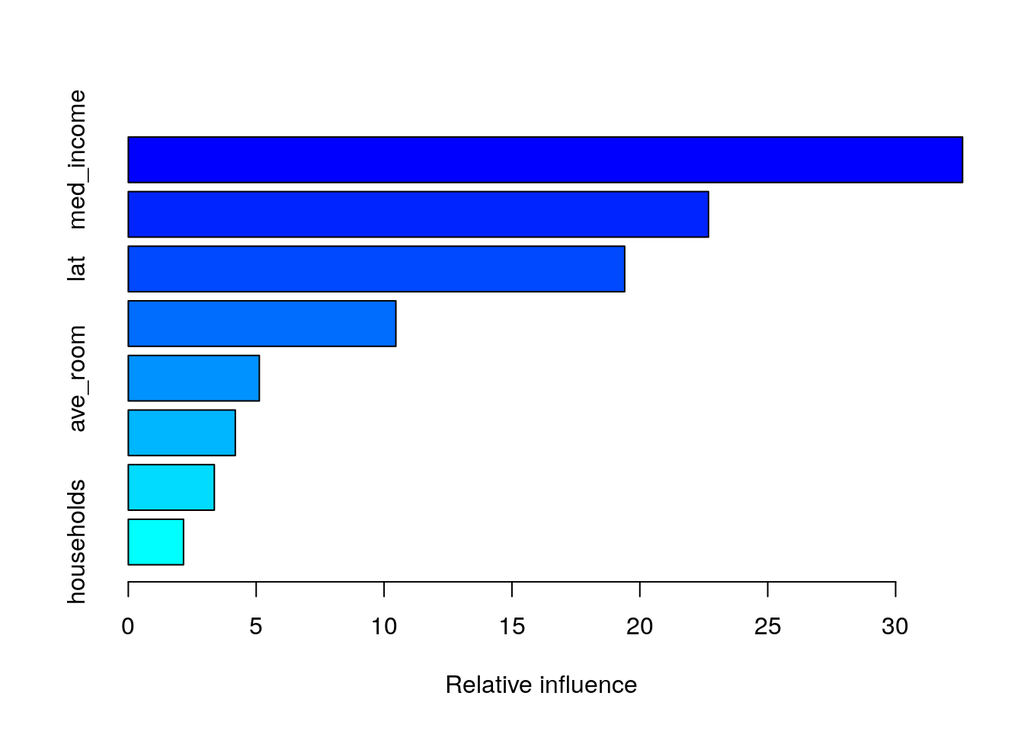

```
##                             var   rel.inf
## med_income           med_income 32.617413
## long                       long 22.683747
## lat                         lat 19.407868
## ave_occupancy     ave_occupancy 10.461677
## ave_room               ave_room  5.122499
## housing_med_age housing_med_age  4.183705
## ave_bedroom         ave_bedroom  3.363590
## households           households  2.159502
```

```r
modelo <- gbm_2(n.trees=800, shrinkage=0.07, interaction.depth=6, bag.fraction=0.5)
summary(modelo)
```

```r
paste("Fin de creación del modelo", Sys.time())
```

```
## [1] "Fin de creación del modelo 2017-11-13 00:48:45"
```

Puedes graficar el error de validación cruzada con

```r
gbm.perf(modelo)
```

```
## Using cv method...
```

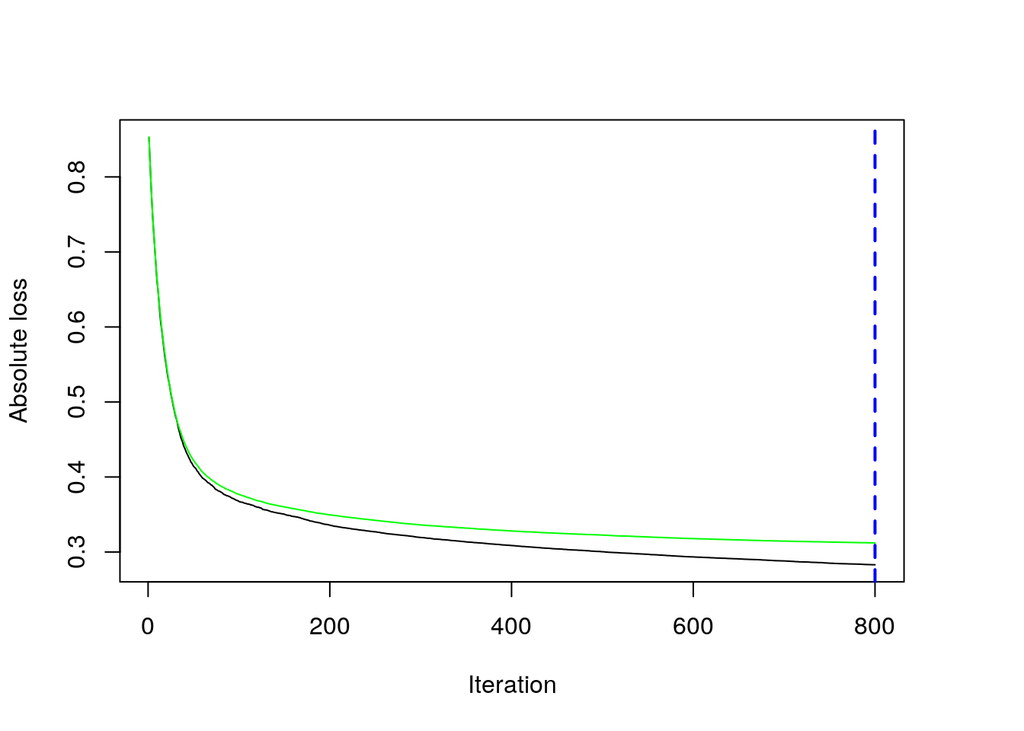

```
## [1] 800
```

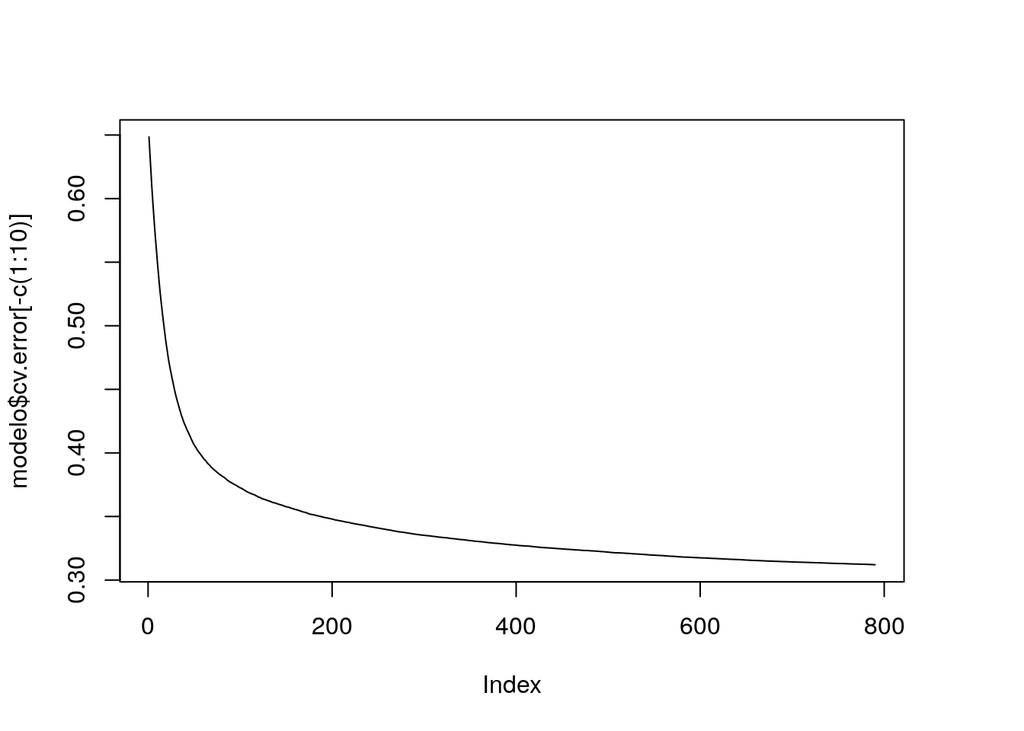

```r
plot(modelo$cv.error[-c(1:10)], type="l") # (opcional) quitar las primeras 10 iteraciones.
```

### Pregunta 3

- Intenta no usar bag.fraction

En este ejemplo, ¿Qué pasa con el error de validación cruzada en el ejemplo anterior si no usas submuestreo? ¿Cuánto tiempo tarda en correr en comparación al modelo anterior?

```r
paste("Inicio de creación del modelo", Sys.time())
```

```
## [1] "Inicio de creación del modelo 2017-11-13 00:48:46"
```

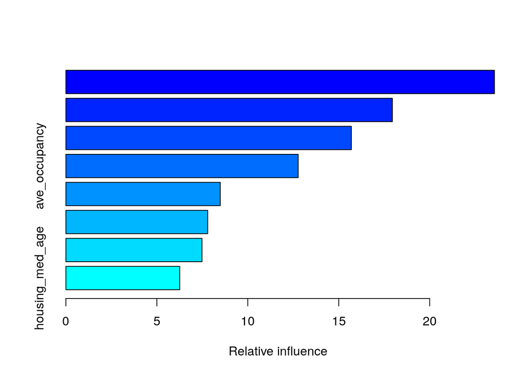

```
##                             var   rel.inf
## med_income           med_income 23.560392
## long                       long 17.949791
## lat                         lat 15.695300
## ave_occupancy     ave_occupancy 12.770456
## ave_room               ave_room  8.485704
## ave_bedroom         ave_bedroom  7.795828
## households           households  7.483228
## housing_med_age housing_med_age  6.259302
```

```r
modelo <- gbm_2(n.trees=800, shrinkage=0.07, interaction.depth=6, bag.fraction=0.1)
summary(modelo)
```

```r
paste("Fin de creación del modelo", Sys.time())
```

```
## [1] "Fin de creación del modelo 2017-11-13 00:49:14"
```

*Los tiempos fueron distintos, aunque no pude poner `bag.fraction=0`. Aquí muestro la diferencia*

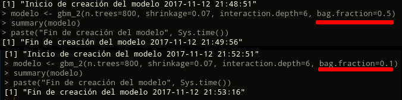

### Pregunta 4

- Tasa de aprendizaje demasiado alta

Intenta poner la tasa de aprendizaje más alta (por ejemplo 0.5) En este ejemplo, ¿Qué pasa con el error de validación cruzada?

```r
modelo <- gbm_2(n.trees=800, shrinkage=0.40, interaction.depth=6, bag.fraction=0.5)
```

```r
gbm.perf(modelo)
```

```
## Using cv method...
```

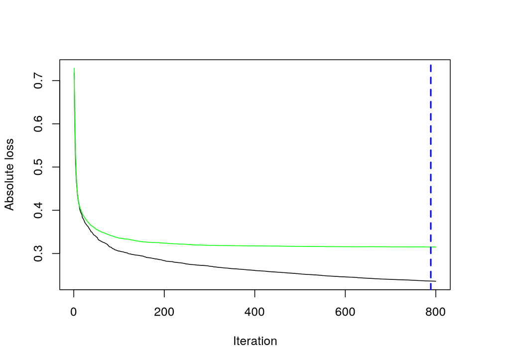

```
## [1] 789
```

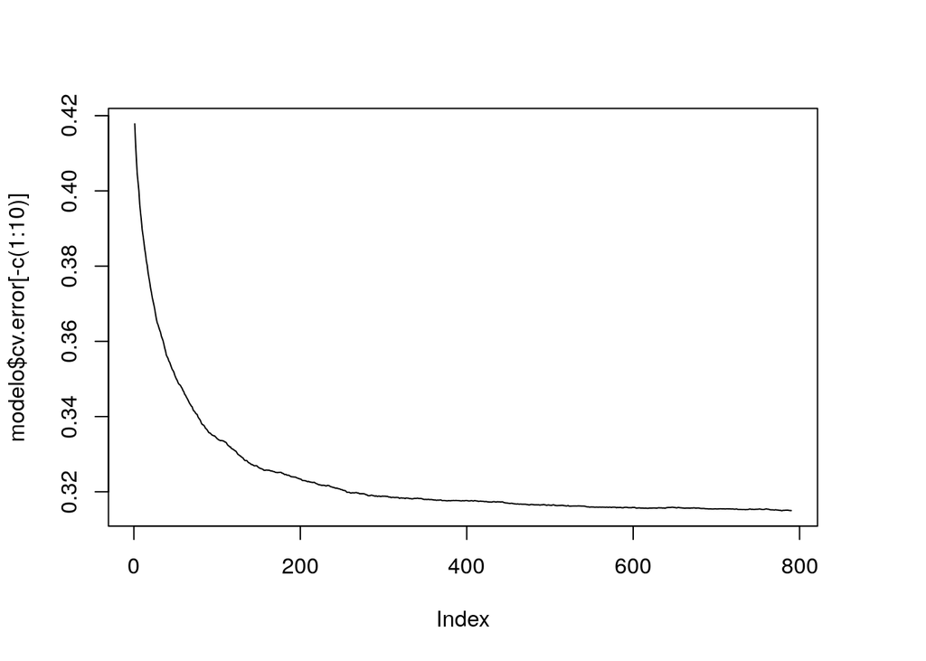

```r
plot(modelo$cv.error[-c(1:10)], type="l") # (opcional) quitar las primeras 10 iteraciones.
```

### Pregunta 5

- Refina tu modelo

Intenta hacer shrinkage un poco más chico y correr el modelo con más iteraciones (n.trees). ¿Qué tan chico pudiste hacer el error de validación cruzada? Si haces shrinkage muy chico, ¿qué tienes qué hacer con el número de árboles (n.trees) para obtener buen desempeño?

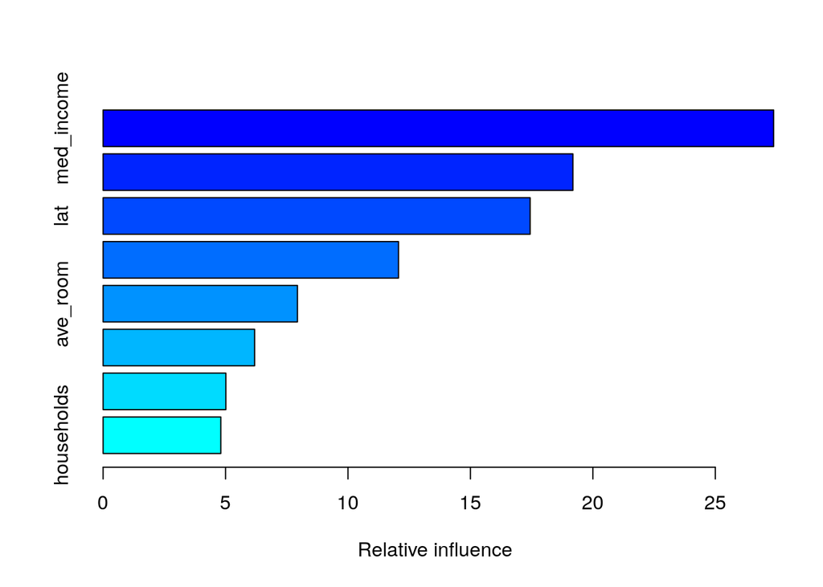

```
##                             var   rel.inf
## med_income           med_income 27.379658
## long                       long 19.183829
## lat                         lat 17.437057
## ave_occupancy     ave_occupancy 12.061470
## ave_room               ave_room  7.935144
## ave_bedroom         ave_bedroom  6.185579
## housing_med_age housing_med_age  5.011320
## households           households  4.805942
```

```r
modelo <- gbm_2(n.trees=800, shrinkage=0.20, interaction.depth=6, bag.fraction=0.5)
summary(modelo)
```

```r
gbm.perf(modelo)
```

```
## Using cv method...
```

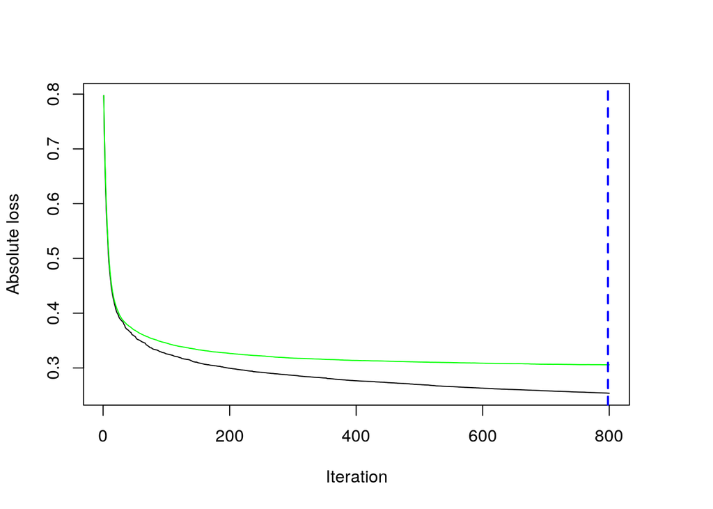

```
## [1] 798
```

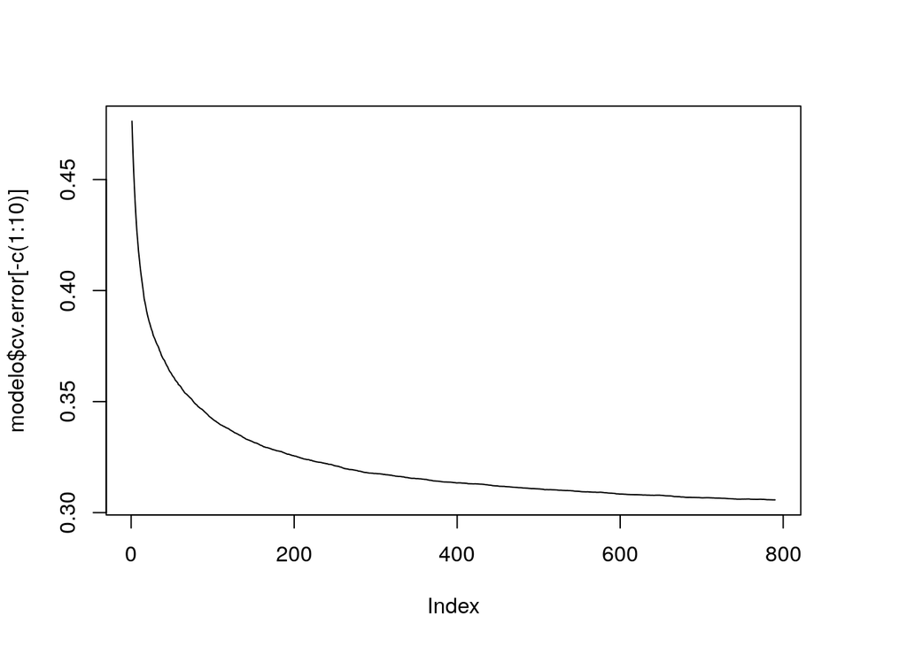

```r
plot(modelo$cv.error[-c(1:10)], type="l")
```

*Aquí aumenté el número de árboles, con el siguiente resultado*

```r
modelo <- gbm_2(n.trees=1000, shrinkage=0.20, interaction.depth=6, bag.fraction=0.5)
summary(modelo)
```

```
##                             var   rel.inf
## med_income           med_income 25.765575
## long                       long 18.488289
## lat                         lat 17.337311
## ave_occupancy     ave_occupancy 12.004523
## ave_room               ave_room  8.317144
## ave_bedroom         ave_bedroom  7.278003
## households           households  5.692000
## housing_med_age housing_med_age  5.117155
```

```r
gbm.perf(modelo)
```

```
## Using cv method...
```

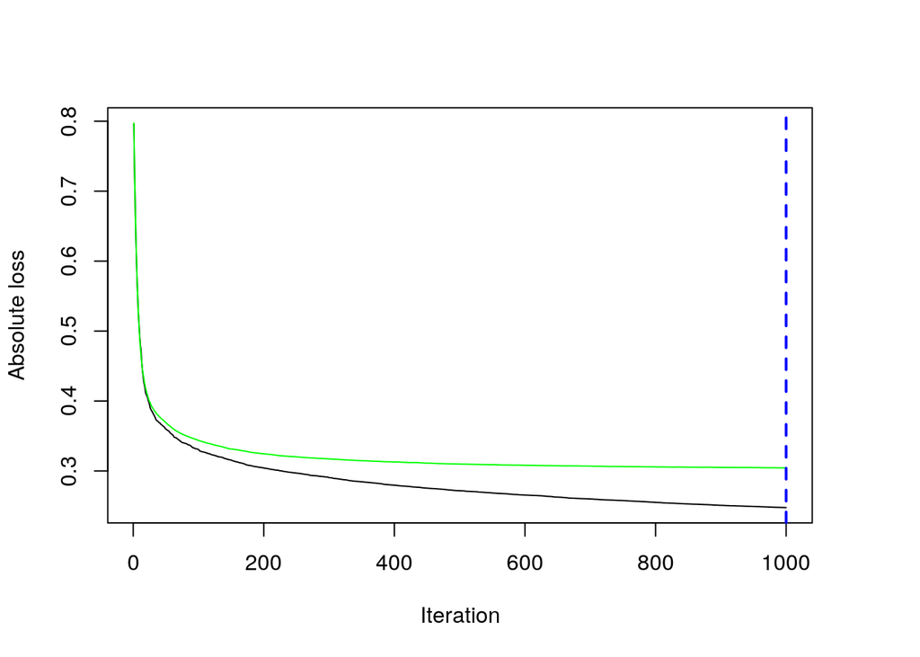

```
## [1] 1000
```

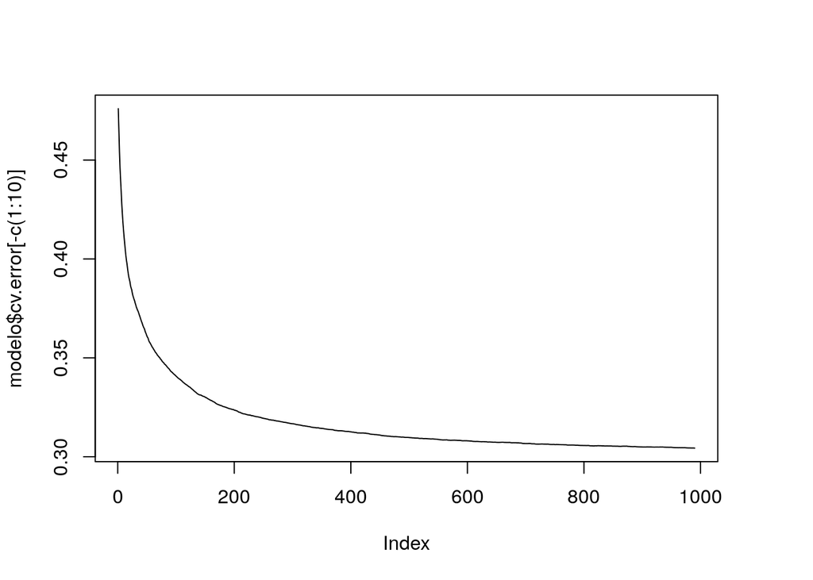

```r
plot(modelo$cv.error[-c(1:10)], type="l")
```

### Pregunta 6

- Evalúa el modelo que seleccionaste

Calcula con la muestra de prueba nuestra estimación final del error de predicción (recuerda usar el error absoluto promedio). Compara con regresión lineal. Haz una gráfica de predicciones de prueba contra valores observados. Calcula el valor en dólares de los 10% más grandes de los errores de prueba y del 10% de los errores más chicos (usa la función quantile).

```r
lm_lineal <- function(){
  cv.glmnet(
    x = data_f_train2[,which(names(data_f_train2) %in%
            c("households", "lat", "long", "ave_room", "ave_bedroom", "housing_med_age", "ave_occupancy"))]%>%as.matrix,
    y = data_f_train2$med_value_scaled,
    alpha = 1, type.measure = "mae" )

}
# summary(data_f_train2)
modelo_lm <- lm_lineal()
1-modelo_lm$lambda.1se
```

```
## [1] 0.9845405
```

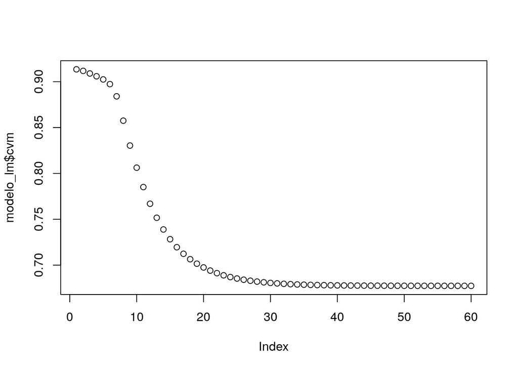

```r
plot(modelo_lm$cvm)
```

*Comparando los errores mínimos observamos que nos fue mejor con `gbm`*

```r
modelo_lm$cvm[modelo_lm$lambda == modelo_lm$lambda.min]
```

```
## [1] 0.6773945
```

```r
modelo$cv.error[modelo$cv.error == min(modelo$cv.error)]
```

```
## [1] 0.3043805
```

### Pregunta 7

*Se realizaron estas pruebas en cada uno, y por eso escogí el modelo*

```r
summary(modelo)
```

```
##                             var   rel.inf
## med_income           med_income 25.765575
## long                       long 18.488289
## lat                         lat 17.337311
## ave_occupancy     ave_occupancy 12.004523
## ave_room               ave_room  8.317144
## ave_bedroom         ave_bedroom  7.278003
## households           households  5.692000
## housing_med_age housing_med_age  5.117155
```

- ¿Cómo es la gráfica de dependencia parcial del ingreso mediano?

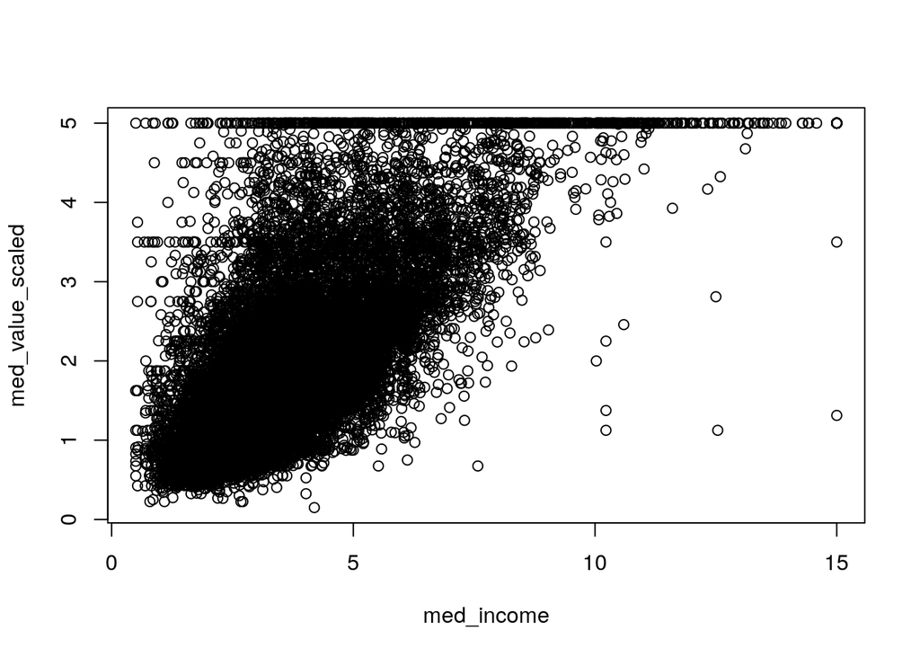

```r
# summary(
#   data_f_train2[,which(names(data_f_train2) %in%
#             c("med_value_scaled", "med_income"))]
# )
plot(data_f_train2[,which(names(data_f_train2) %in%
            c("med_value_scaled", "med_income"))])
```

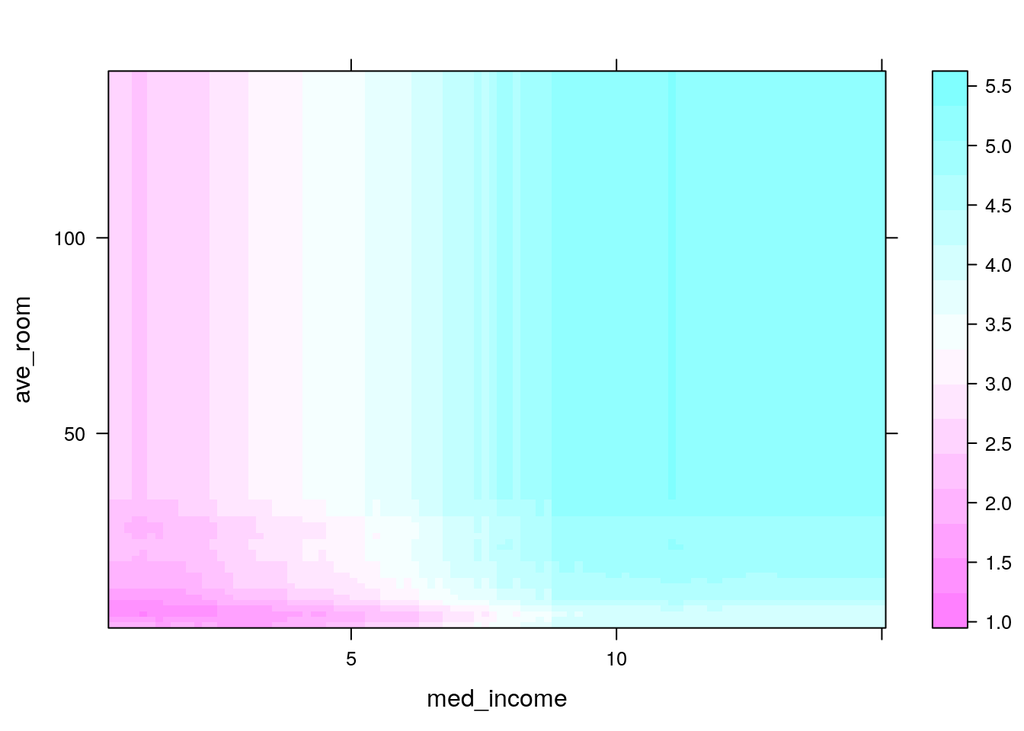

```r
plot(modelo, i.var=c(1,5))
```

```r
summary(modelo)
```

```
##                             var   rel.inf
## med_income           med_income 25.765575
## long                       long 18.488289
## lat                         lat 17.337311
## ave_occupancy     ave_occupancy 12.004523
## ave_room               ave_room  8.317144
## ave_bedroom         ave_bedroom  7.278003
## households           households  5.692000
## housing_med_age housing_med_age  5.117155
```

- ¿Cómo es la gráfica de dependencia parcial de la variable households? ¿Qué puedes decir de la variación que ves para valores grandes de households? (Considera dónde está la mayoría de los datos de household). ¿Cómo rediseñarías esta gráfica si quisieras presentarla para explicar el efecto de esta variable?
- Usualmente, latitud y longitud sólo tiene sentido considerarlas juntas en una gráfica de dependencia parcial (como interacción). Haz la gráfica de dependencia parcial para estas dos variables

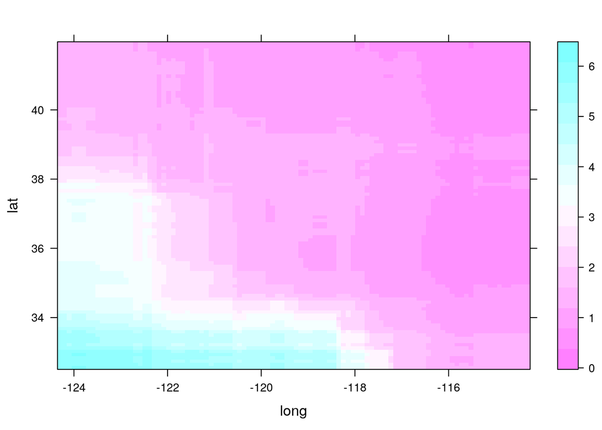

```r
# Latitud y longitud sólo tienen sentido como interacción
plot(modelo, i.var=c(4,3))
```

Sobrepone al mapa para entender esta relación. Puedes usar el siguiente código:

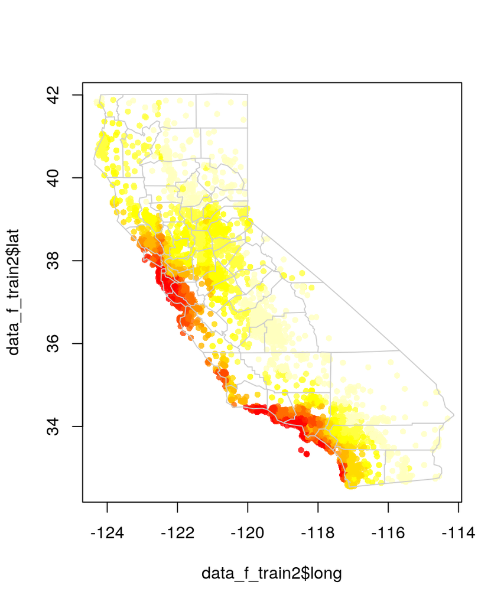

```r
# fit_boost es el modelo final que ajustaste
# obtener los datos de la gráfica de dependencia parcial
grid_pos <- plot(modelo, i.var=c(4,3), n.trees=1000, return.grid=TRUE)

# Calcular con 1 vecino más cercano el valor de dependencia parcial
# para cada caso de entrenamiento (no son los mismos valores)
knn_1 <- kknn(y~long+lat, grid_pos, data_f_train2[ , c("long","lat")], k=1,
    kernel="rectangular")
data_f_train2$lat_long_partial <- knn_1$fitted.values
# Cortar para obtener colores
data_f_train2$lat_long_partial_cat <- cut2(data_f_train2$lat_long_partial, g=10)
plot(data_f_train2$long, data_f_train2$lat,
     col=rev(heat.colors(10, alpha=0.8))[data_f_train2$lat_long_partial_cat], pch=16,
        cex=0.8)
map('county','california', add=TRUE, col="gray80")
```

¿Cuáles son las zonas más caras de California?

*Las zonas costeras. En particular: (en el siguiente orden)*

++ *San Francisco Bay Area* ++ *Los Angeles Basin* ++ *San Diego*

*A mí me sorprendió que no figurara Lake Tahoe o Sacramento*